# Predicting quality of weight lifting exercises using data from wearable devices

Irena Papst

## Background and motivation

Wearable activity monitors have become quite popular and increasingly inexpensive, enabling individuals to automatically track many features of the phyiscal activity they perform each day: from type of exercise to duration to frequency. While a sufficient quantity of regular exercise is important for improving and maintaining good health, the *quality* of exercise performed is also consequential. This feature is difficult to track directly, but it may perhaps be inferred from data gathered using wearable devices.

The goal of this project is to use data collected by a wearable activity monitor to predict the quality of a weight-lifting exercise performed.

## Data

We use data from the Weight Lifting Exercises Dataset (Velloso et al. 2013). Six young and healthy participants were asked to perform one set of 10 repetitions of the unilateral dumbbell bicep curl perfectly (class A), or with one of four mistakes: throwing elbows to the front (class B), lifting or lowering the dumbell only halfway (classes C and D, respectively), and throwing the hips to the front (class E). While the participants had little weight lifting experience, they were supervised by an experienced weight lifter to ensure the exercises were completed in the manner specified, and they used a relatively light dumbell (1.25 kg).

Four orientation sensors tracked the exercises and were located on the dumbell, as well as on the participant’s upper arm, forearm, and belt. These sensors record roll, pitch, yaw, total acceleration (four measurements per sensor for a total of 16 measurements), as well as gyroscope, accelerometer, and magnetoscope readings for each of the $x$, $y$, and $z$ coordinates (three measurements per coordinate per sensor for a total of 36 measurements). As a result, we have a maximum of 52 measurements upon which we can base our prediction.

```r
## Training data
training <- training %>%
  ## Filter training to remove rows with summary stats
  ## (none to predict in the test set so probably not relevant)
  filter(new_window == "no") %>%
  ## Remove cols where all vals are NA
  map(~.x) %>%
  discard(~all(is.na(.x))) %>%
  map_df(~.x) %>%
  ## Remove cols irrelevant to prediction
  select(-c(X1, user_name,
            raw_timestamp_part_1, raw_timestamp_part_2,
            cvtd_timestamp,
            new_window, num_window))

## Testing data
testing <- testing %>%
    ## Remove cols where all vals are NA
  map(~.x) %>%
  discard(~all(is.na(.x))) %>%
  map_df(~.x) %>%
  ## Remove cols irrelevant to prediction
  select(-c(X1, user_name,
            raw_timestamp_part_1, raw_timestamp_part_2,
            cvtd_timestamp,
            new_window, num_window))
```

## Model

We are trying to predict a categorical outcome with more than two values with continuous predictors, so linear or logistic regression are inapporpriate. Naive Bayes requires the assumption that the data follows a probabilistic model, but we have no reason to assume particular distributions for our predictors. Instead, we choose a random forest as it is compatible with our input data and can be very accurate. It is true that random forests can be slow and hard to interpret, but these are not major concerns here, as we seek to run this experiment only once and are primarily interested in accuracy and not model interpretability.

### Feature selection

Another issue with random forests is the potential for overfitting. We start with the full model (52 predictors) and proportionally reduce the number of predictors by 1/2 at each step, keeping only the most important variables with respect to their associated mean difference in accuracy of results. We also compute the cross-validated prediction performance of these models. Both of these steps are achieved using the `rfcv()` function from the `randomForest` package with its default values: 5-fold cross-validation, $\max\{ 1, \rm{floor}(p)\}$ predictors to try at each node, where $p$ is the remaining number of predictors.

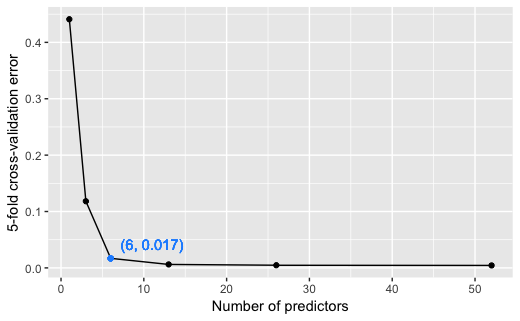

Remarkably, even with just 6 variables out of a possible 52, the model still achieves a $1.7 \%$ error rate, for an accuracy of $98.3 \%$.

Next, we train another random forest model on all 52 predictors, so that we may find the 6 most important ones for our final model. We use the default values in the `randomForest()` function, keeping track of the importance of each predictor for correctly classifying each outcome type.

```r
head(importance(full_model))
```

```
                        A        B        C        D        E
roll_belt        39.86730 50.71397 48.13441 48.11209 45.35802
pitch_belt       32.24888 54.33655 42.49771 37.18539 32.62118
yaw_belt         50.62138 46.37720 43.55333 48.30038 33.06081
total_accel_belt 16.58525 18.85909 15.67582 16.41683 16.06406
gyros_belt_x     18.77969 17.43840 19.83565 14.97147 19.43016
gyros_belt_y     12.37630 18.02730 16.91820 16.06702 18.14560
                 MeanDecreaseAccuracy MeanDecreaseGini
roll_belt                    58.03105       1257.06994
pitch_belt                   51.80831        705.02063
yaw_belt                     64.26396        907.36777
total_accel_belt             19.94874        222.54458
gyros_belt_x                 26.79591         89.03794
gyros_belt_y                 21.38127        115.94704
```

Since we are most interested in accuracy, we sort the list of predictors by mean decrease in accuracy (after permuting predictors, averaged over all trees) recorded during model training and choose the six most important predictors (where a larger number indicates more importance in the model):

```r
names(sort(importance(full_model)[,6], decreasing = TRUE))[1:6]
```

```
[1] "yaw_belt"          "roll_belt"         "pitch_belt"
[4] "magnet_dumbbell_z" "pitch_forearm"     "magnet_dumbbell_y"
```

## References

Velloso, Eduardo, Andreas Bulling, Hans Gellersen, Wallace Ugulino, and Hugo Fuks. 2013. “Qualitative Activity Recognition of Weight Lifting Exercises.” In *Proceedings of the 4th Augmented Human International Conference*, 116–23. ACM.